# Visualize Numerical Data

Applied Statistics

Solutions

2025-03-01

# Syllabus Reminders

- You must submit your worksheet individually by end-of-class or end-of-day. Your name must exist in your worksheet and the names of your collaborators.
- Worksheets are marked mostly on completion, and partially on correctness. It will be marked either pass or fail, there will no detailed feedback on worksheets, and no opportunities for revisions and make-up.

# Instructions

- For the exercises, please provide your answers in full sentences.
- Write your answers by replacing the text “[Write your answer here]”.
- Whenever a problem asks you to run something in R, create an R code chunk and write your R commands inside that chunk.
- If a problem requires modifying an existing R code chunk, make the necessary changes at the appropriate lines within the given code.
- Please read the problems fully and carefully before answering.
- When finished, knit this `.Rmd` to `.html`.
- Submit this `.Rmd` and the recently knitted `.html` to Moodle.

# Packages

The following R packages have already been loaded for you, so there’s no need to load them yourself—they will be used in the problem sets. If you need any additional packages, you can load them here as well.

```r
# load packages
library(tidyverse)
```

# Collaborators

Solutions

# Exercises

## Problem 1

Create a code chunk. In this chunk, load the `palmerpenguins` package. These packages are pre-installed.

```r
library(palmerpenguins)
```

## Problem 2

Examine the `penguins` tibble. You may notice that there are `NA` values, which means missing data. Use the `drop_na()` function to remove all rows that has missing values on any column. Here, you may use chaining to pipe the tibble into `drop_na()`, and save the new tibble as a new R variable. How many rows was removed in the data set?

```r
df <- penguins %>%
  drop_na()
```

There were 344 rows in the `penguins` tibble and 333 rows when the `NA` values are removed.

## Problem 3

Replicate the following plot. Use the `NA` omitted `penguins` tibble you established in Problem 2. Use the `ggplot2` function `geom_point()`.

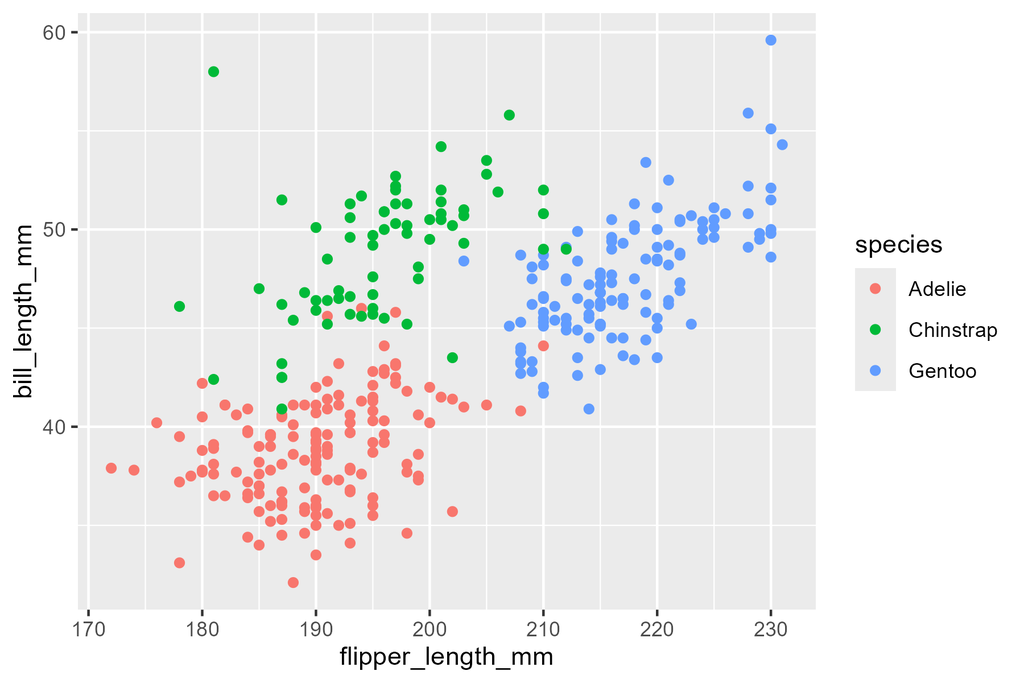

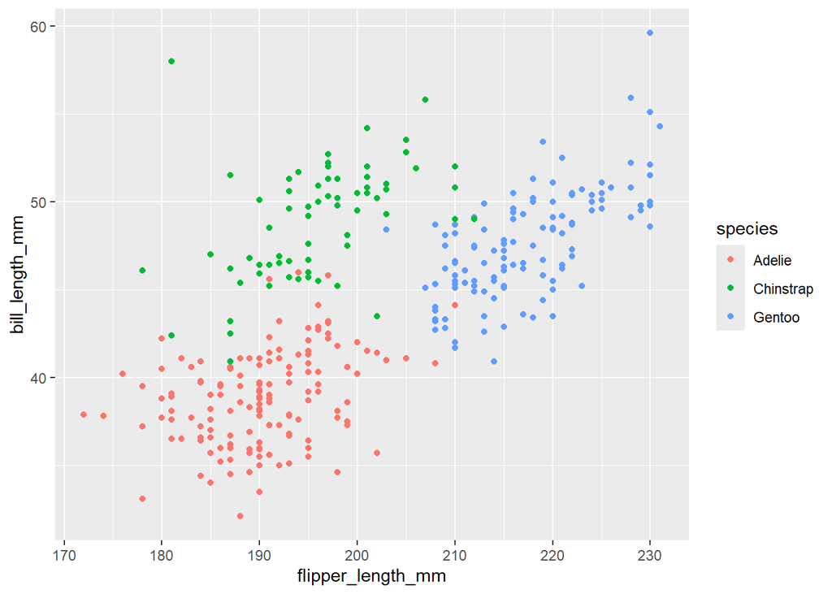

```r
ggplot(df,aes(x=flipper_length_mm,y=bill_length_mm,color=species)) +
  geom_point()
```

## Problem 4

Use the `ggplot()` function `geom_histogram()` to replicate the following plot using the `NA` omitted `penguins` tibble you established in Problem 2. You may need to adjust the `bins` option in `geom_histogram()` to match the plot.

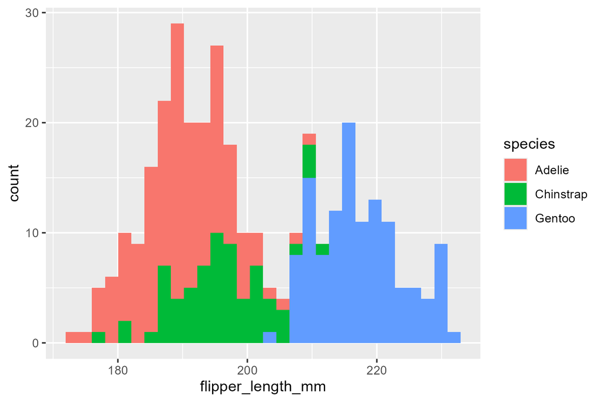

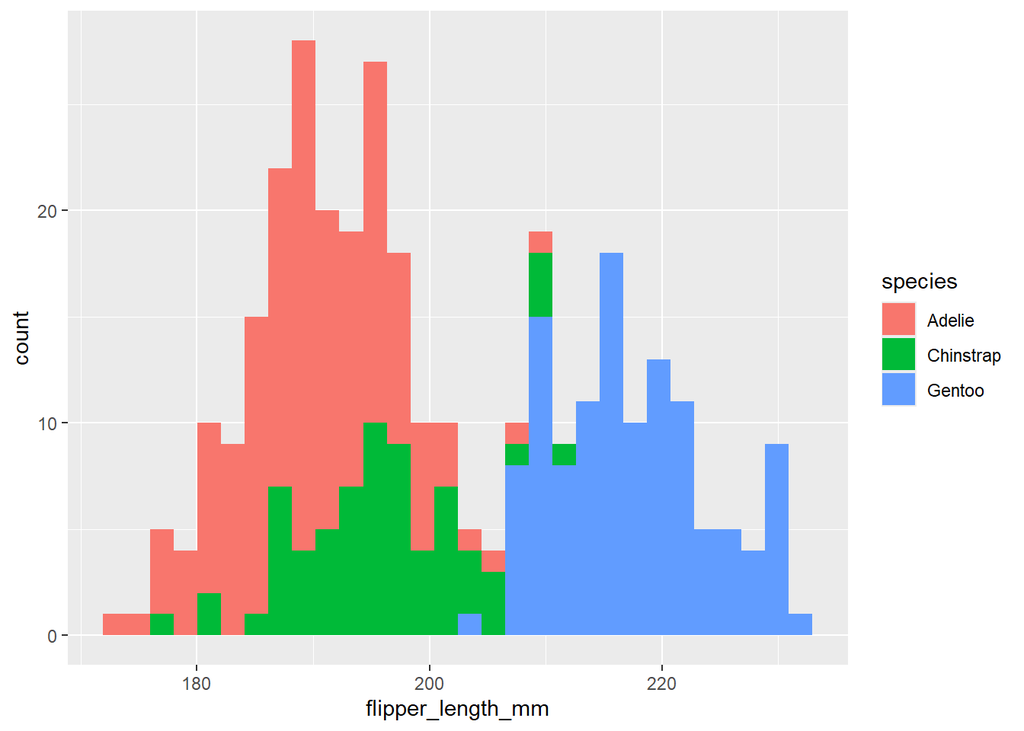

```r
ggplot(df,aes(x=flipper_length_mm,fill=species)) +
  geom_histogram(bins=30)
```

## Problem 5

Create two plots similar to Problems 3 and 4, but instead of using the `species`, use the `sex` variable to group the numerical variables.

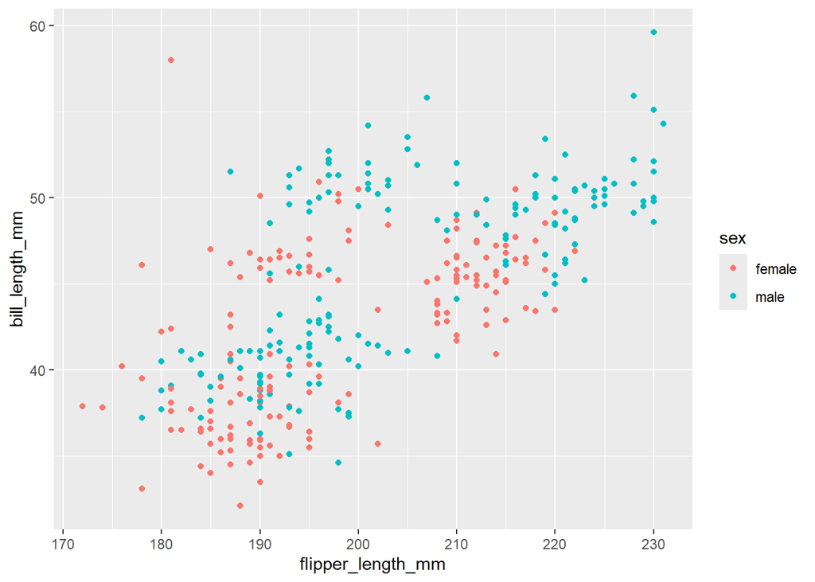

```r
# scatterplot
ggplot(df,aes(x=flipper_length_mm,y=bill_length_mm,color=sex)) +
  geom_point()
```

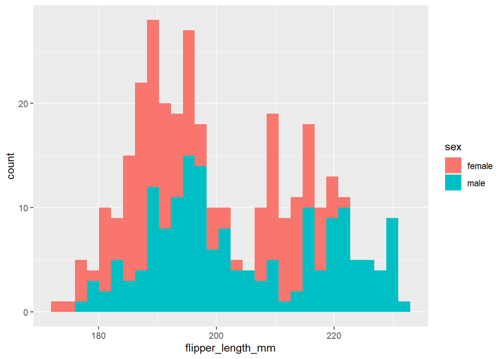

```r
# histogram
ggplot(df,aes(x=flipper_length_mm,fill=sex)) +
  geom_histogram(bins=30)
```